# Homework-Week-6

```r
knitr::opts_chunk$set(
    echo = TRUE,
    warning = FALSE,
    comment = "##",
    prompt = TRUE,
    tidy=TRUE,
    tidy.opts = list(width.cutoff = 75),
    fig.path = "img/"
)
```

# [1]Write a simple R function, Z.prop.test(), that can perform one- or two-sample Z-tests for proportion data, using the following guidelines.

### Your function should take the following arguments: p1 and n1 (no default) to pose as the estimated proportion and sample size (i.e., based on your sample data); p2 and n2 (both defaulting to NULL) that contain a second sample’s proportion and sample size data in the event of a two-sample test; p0 (no default) as the expected value for the population proportion; and alternative (default “two.sided”) and conf.level (default 0.95), to be used in the same way as in the function t.test().

### When conducting a two-sample test, it should be p1 that is tested as being smaller or larger than p2 when alternative=“less” or alternative=“greater”, the same as in the use of x and y in the function t.test().

### The function should perform a one-sample Z-test using p1, n1, and p0 if either p2 or n2 (or both) is NULL.

### The function should contain a check for the rules of thumb we have talked about ($n * p > 5$ and $n * (1-p) >5$) to ensure the validity of assuming the normal distribution in both the one- and two-sample settings. If this is violated, the function should still complete but it should also print an appropriate warning message.

### The function should return a list containing the members Z (the test statistic), P (the appropriate p-value), and CI (the two-sided CI with respect to confidence level).

```r
> Z.prop.test <- function(p1, n1, p2 = NULL, n2 = NULL, p0, alternative = "two.sided",
+     conf.level = 0.95) {
+     # this step set up the structure and default values for the function
+     if (is.nul(p2) || is.null(n2)) {
+         # first criterion check determines whether we run a one sample or two sample
+         # test
+         if (n1 * p1 <= 5 || n1 * (1 - p1) <= 5) {
+             warning("Warning: Normal Dist Invalid")  #Checking validity of normal distribution
+         }
+         z <- (p1 - p0)/sqrt(p0(1 - p0)/n1)
+         CI <- (p1) + c(-1, 1) * qnorm(conf.level + (1 - conf.level)/2) * sqrt(p0 *
+             (1 - p0)/n1)
+     } else {
+         # second scenario in which p2 and n2 are not null - 2 sample test
+         if (p1 * n1 <= 5 || n1 * (1 - p1) <= 5 || p2 * n2 <= 5 || n2 * (1 -
+             p2) <= 5)
+             {
+                 warning("Warning: Normal Dist Invalid")
+             }  #if validity is satisfied, a one sample test is run
+         pstar <- (p1 * n1 + p2 * n2)/(n1 + n2)
+         z <- (p2 - p1 - p0)/sqrt(pstar * (1 - pstar) * ((1/n1) + (1/n2)))
+         CI <- sort((p1 - p2) + c(-1, 1) * qnorm(conf.level + (1 - conf.level)/2) *
+             sqrt(pstar * (1 - pstar) * ((1/n1) + (1/n2))))
+         if (alternative == "greater") {
+             # if we specify 'greater', we want a one-sided upper tail test like this:
+             p <- pnorm(z, lower.tail = FALSE)
+         } else if (alternative == "less") {
+             # if we specify 'greater', we want a one-sided lower tail test like this:
+             p <- pnorm(z, lower.tail = TRUE)
+         } else if (alternative == "two.sided") {
+             # the default argument is for a two-tailed test like this:
+             if (z > 0) {
+                 p <- 2 * pnorm(z, lower.tail = F)
+             }
+             if (z < 0) {
+                 p <- 2 * pnorm(z, lower.tail = T)
+             }
+         }
+         return(list(z = z, p = p, CI = CI))  #return results in list format
+     }
+ }
```

# [2] The dataset from Kamilar and Cooper has in it a large number of variables related to life history and body size. For this exercise, the end aim is to fit a simple linear regression model to predict longevity (“MaxLongevity_m”) measured in months from species’ brain size (“Brain_Size_Species_Mean”) measured in grams. Do the following for both longevity~brain size and log(longevity)~log(brain size).

```r
> # Fit the regression model and, using {ggplot2}, produce a scatterplot with
> # the fitted line superimposed upon the data. Append the the fitted model
> # equation to your plot.
> library(curl)
> f <- curl("https://raw.githubusercontent.com/difiore/ADA2016/master/KamilarAndCooperData.csv")
> d <- read.csv(f, header = TRUE, sep = ",", stringsAsFactors = FALSE)
> log_brain <- log(d$Brain_Size_Species_Mean)
> log_longevity <- log(d$MaxLongevity_m)
> df <- cbind(d, log_brain, log_longevity)
> library(ggplot2)
>
> # Maximum longevity regressed on brain size:
>
> m <- lm(data = df, MaxLongevity_m ~ Brain_Size_Species_Mean)
> summary(m)
```

```
##
## Call:
## lm(formula = MaxLongevity_m ~ Brain_Size_Species_Mean, data = df)
##
## Residuals:
##     Min      1Q  Median      3Q     Max
## -198.27  -61.92  -17.78   56.16  331.36
##
## Coefficients:
##                         Estimate Std. Error t value Pr(>|t|)
## (Intercept)             248.9523    11.1111   22.41   <2e-16 ***
## Brain_Size_Species_Mean   1.2180     0.1101   11.06   <2e-16 ***
## ---
## Signif. codes:  0 '***' 0.001 '**' 0.01 '*' 0.05 '.' 0.1 ' ' 1
##
## Residual standard error: 90.91 on 126 degrees of freedom
##   (85 observations deleted due to missingness)
## Multiple R-squared:  0.4928, Adjusted R-squared:  0.4887
## F-statistic: 122.4 on 1 and 126 DF,  p-value: < 2.2e-16
```

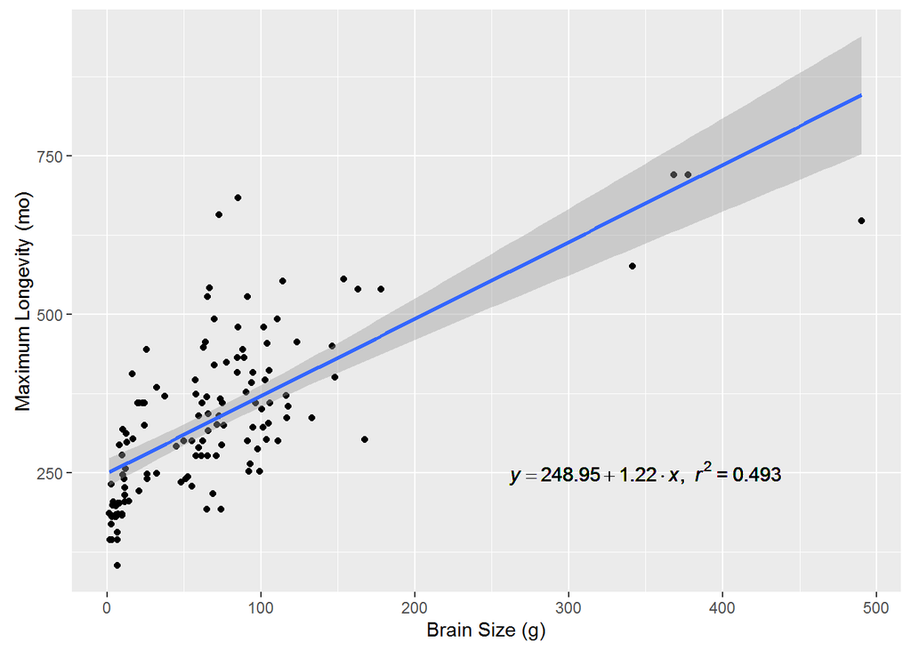

```r
> lm_eqn = function(m) {
+     l <- list(a = format(coef(m)[1], digits = 5), b = format(abs(coef(m)[2]),
+         digits = 3), r2 = format(summary(m)$r.squared, digits = 3))
+     if (coef(m)[2] >= 0) {
+         eq <- substitute(italic(y) == a + b %.% italic(x) * "," ~ ~italic(r)^2 ~
+             "=" ~ r2, l)
+     } else {
+         eq <- substitute(italic(y) == a - b %.% italic(x) * "," ~ ~italic(r)^2 ~
+             "=" ~ r2, l)
+     }
+     as.character(as.expression(eq))
+ }
> regression_plot <- ggplot(data = df, aes(x = df$Brain_Size_Species_Mean, y = df$MaxLongevity_m)) +
+     xlab("Brain Size (g)") + ylab("Maximum Longevity (mo)") + geom_point() +
+     geom_smooth(method = "lm", formula = y ~ x) + geom_text(aes(x = 350, y = 250,
+     label = lm_eqn(lm(df$MaxLongevity_m ~ df$Brain_Size_Species_Mean, df))),
+     parse = TRUE)
> regression_plot
```

```r
> # Log-transformed maximum longevity regressed on log-transformed brain size:
>
> log_m <- lm(data = df, log_longevity ~ log_brain)
> summary(log_m)
```

```
##
## Call:
## lm(formula = log_longevity ~ log_brain, data = df)
##
## Residuals:
##     Min      1Q  Median      3Q     Max
## -0.6955 -0.1750 -0.0097  0.1788  0.6084
##
## Coefficients:
##             Estimate Std. Error t value Pr(>|t|)
## (Intercept)  4.87895    0.06907   70.63   <2e-16 ***
## log_brain    0.23415    0.01781   13.15   <2e-16 ***
## ---
## Signif. codes:  0 '***' 0.001 '**' 0.01 '*' 0.05 '.' 0.1 ' ' 1
##
## Residual standard error: 0.2485 on 126 degrees of freedom
##   (85 observations deleted due to missingness)
## Multiple R-squared:  0.5784, Adjusted R-squared:  0.5751
## F-statistic: 172.9 on 1 and 126 DF,  p-value: < 2.2e-16
```

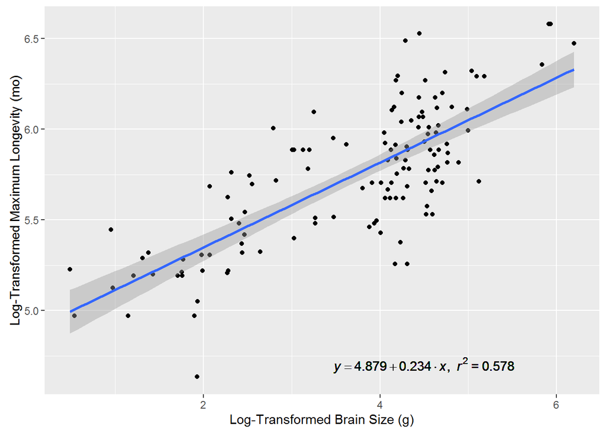

```r
> lm_eqn = function(log_m) {
+
+     l <- list(a = format(coef(log_m)[1], digits = 5), b = format(abs(coef(log_m)[2]),
+         digits = 3), r2 = format(summary(log_m)$r.squared, digits = 3))
+     if (coef(log_m)[2] >= 0) {
+         eq <- substitute(italic(y) == a + b %.% italic(x) * "," ~ ~italic(r)^2 ~
+             "=" ~ r2, l)
+     } else {
+         eq <- substitute(italic(y) == a - b %.% italic(x) * "," ~ ~italic(r)^2 ~
+             "=" ~ r2, l)
+     }
+     as.character(as.expression(eq))
+ }
>
> log_regression_plot <- ggplot(data = df, aes(x = df$log_brain, y = df$log_longevity)) +
+     xlab("Log-Transformed Brain Size (g)") + ylab("Log-Transformed Maximum Longevity (mo)") +
+     geom_point() + geom_smooth(method = "lm", formula = y ~ x) + geom_text(aes(x = 4.5,
+     y = 4.7, label = lm_eqn(lm(df$log_longevity ~ df$log_brain, df))), parse = TRUE)
> log_regression_plot
```

```r
> # Identify and interpret the point estimate of the slope ($\beta_1$), as
> # well as the outcome of the test associated with the hypotheses H0:
> # $\beta_1$ = 0; HA: $\beta_1$ <U+2260> 0. Also, find a 90 percent CI for
> # the slope ($\beta_1$) parameter.
>
> # Original variables:
> summary(m)
```

```
##
## Call:
## lm(formula = MaxLongevity_m ~ Brain_Size_Species_Mean, data = df)
##
## Residuals:
##     Min      1Q  Median      3Q     Max
## -198.27  -61.92  -17.78   56.16  331.36
##
## Coefficients:
##                         Estimate Std. Error t value Pr(>|t|)
## (Intercept)             248.9523    11.1111   22.41   <2e-16 ***
## Brain_Size_Species_Mean   1.2180     0.1101   11.06   <2e-16 ***
## ---
## Signif. codes:  0 '***' 0.001 '**' 0.01 '*' 0.05 '.' 0.1 ' ' 1
##
## Residual standard error: 90.91 on 126 degrees of freedom
##   (85 observations deleted due to missingness)
## Multiple R-squared:  0.4928, Adjusted R-squared:  0.4887
## F-statistic: 122.4 on 1 and 126 DF,  p-value: < 2.2e-16
```

```r
> t <- coef(summary(m))
> t <- data.frame(unlist(t))
> colnames(t) <- c("Est", "SE", "t", "p")
> t
```

```
##                               Est         SE       t            p
## (Intercept)             248.95227 11.1111143 22.4057 8.910319e-46
## Brain_Size_Species_Mean   1.21799  0.1100879 11.0638 2.685909e-20
```

```r
> t$calct <- (t$Est - 0)/t$SE
> t$calcp <- 2 * pt(t$calct, df = 998, lower.tail = FALSE)
> t
```

```
##                               Est         SE       t            p   calct
## (Intercept)             248.95227 11.1111143 22.4057 8.910319e-46 22.4057
## Brain_Size_Species_Mean   1.21799  0.1100879 11.0638 2.685909e-20 11.0638
##                                calcp
## (Intercept)             2.155214e-90
## Brain_Size_Species_Mean 6.412865e-27
```

```r
> t$lower <- t$Est - qt(0.95, df = 998) * t$SE
> t$upper <- t$Est + qt(0.95, df = 998) * t$SE
> ci <- c(t$lower, t$upper)  # by hand
> ci
```

```
## [1] 230.659128   1.036744 267.245403   1.399237
```

```r
> ci <- confint(m, level = 0.9)
> ci
```

```
##                                5 %      95 %
## (Intercept)             230.540738 267.36379
## Brain_Size_Species_Mean   1.035571   1.40041
```

## Discussion: Beta1 is equal to ~1.218. This means that for every 1 gram increase in brain size we can expect an increase in maximum longevity of ~1.218 months. The p-value associated with beta1 is very well under 0.05; therefore we can reject the null hypothesis that beta1 = 0.

```r
> # Log-transformed variables:
> summary(log_m)
```

```
##
## Call:
## lm(formula = log_longevity ~ log_brain, data = df)
##
## Residuals:
##     Min      1Q  Median      3Q     Max
## -0.6955 -0.1750 -0.0097  0.1788  0.6084
##
## Coefficients:
##             Estimate Std. Error t value Pr(>|t|)
## (Intercept)  4.87895    0.06907   70.63   <2e-16 ***
## log_brain    0.23415    0.01781   13.15   <2e-16 ***
## ---
## Signif. codes:  0 '***' 0.001 '**' 0.01 '*' 0.05 '.' 0.1 ' ' 1
##
## Residual standard error: 0.2485 on 126 degrees of freedom
##   (85 observations deleted due to missingness)
## Multiple R-squared:  0.5784, Adjusted R-squared:  0.5751
## F-statistic: 172.9 on 1 and 126 DF,  p-value: < 2.2e-16
```

```r
> log_t <- coef(summary(log_m))
> log_t <- data.frame(unlist(log_t))
> colnames(log_t) <- c("log_Est", "log_SE", "log_t", "log_p")
> log_t
```

```
##               log_Est     log_SE    log_t         log_p
## (Intercept) 4.8789509 0.06907361 70.63408 3.321721e-103
## log_brain   0.2341496 0.01780887 13.14792  2.165214e-25
```

```r
> log_t$log_calct <- (log_t$log_Est - 0)/log_t$log_SE
> log_t$log_calcp <- 2 * pt(log_t$log_calct, df = 998, lower.tail = FALSE)
> log_t
```

```
##               log_Est     log_SE    log_t         log_p log_calct
## (Intercept) 4.8789509 0.06907361 70.63408 3.321721e-103  70.63408
## log_brain   0.2341496 0.01780887 13.14792  2.165214e-25  13.14792
##                log_calcp
## (Intercept) 0.000000e+00
## log_brain   1.570067e-36
```

```r
> log_ci <- confint(log_m, level = 0.9)
> log_ci
```

```
##                   5 %      95 %
## (Intercept) 4.7644934 4.9934084
## log_brain   0.2046396 0.2636595
```

```r
> # Using your model, add lines for the 90 percent confidence and prediction
> # interval bands on the plot and add a legend to differentiate between the
> # lines.
>
> # Original Variables:
> ci <- predict(m, newdata = data.frame(Brain_Size_Species_Mean = df$Brain_Size_Species_Mean),
+     interval = "confidence", level = 0.9)  # for a vector of values
> head(ci)
```

```
##        fit      lwr      upr
## 1 319.6201 306.1354 333.1047
## 2       NA       NA       NA
## 3 313.3109 299.6449 326.9768
## 4 313.0551 299.3805 326.7297
## 5 311.9224 298.2081 325.6366
## 6 309.7056 295.9081 323.5032
```

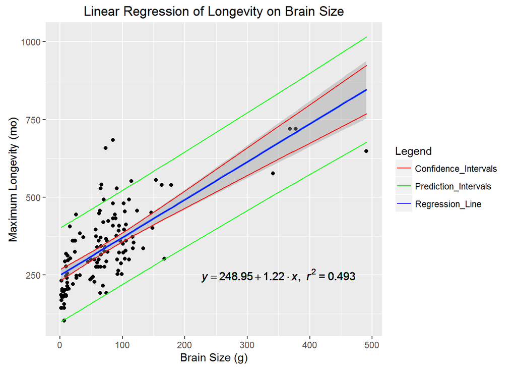

```r
> df <- cbind(df, ci)
> pi <- predict(m, newdata = data.frame(Brain_Size_Species_Mean = df$Brain_Size_Species_Mean),
+     interval = "prediction", level = 0.9)
> colnames(pi) <- c("pi_fit", "pi_lwr", "pi_upr")
> df <- cbind(df, pi)
> regression_plot <- regression_plot + geom_line(aes(x = df$Brain_Size_Species_Mean,
+     y = df$fit, colour = "Regression_Line")) + geom_line(aes(x = df$Brain_Size_Species_Mean,
+     y = df$lwr, colour = "Confidence_Intervals")) + geom_line(aes(x = df$Brain_Size_Species_Mean,
+     y = df$upr, colour = "Confidence_Intervals")) + geom_line(data = df, aes(x = df$Brain_Size_Species_Mean,
+     y = df$pi_lwr, colour = "Prediction_Intervals")) + geom_line(data = df,
+     aes(x = df$Brain_Size_Species_Mean, y = df$pi_upr, colour = "Prediction_Intervals")) +
+     scale_colour_manual(name = "Legend", values = c(Regression_Line = "blue",
+         Confidence_Intervals = "red", Prediction_Intervals = "green")) + ggtitle("Linear Regression of Longevity on Brain Size")
> regression_plot
```

```r
> # Log-transformed variables:
> log_ci <- predict(log_m, newdata = data.frame(log_brain = df$log_brain), interval = "confidence",
+     level = 0.9)
> colnames(log_ci) <- c("log_fit", "log_lwr", "log_upr")
> df <- cbind(df, log_ci)
> log_pi <- predict(log_m, newdata = data.frame(log_brain = df$log_brain), interval = "prediction",
+     level = 0.9)
> colnames(log_pi) <- c("log_pi_fit", "log_pi_lwr", "log_pi_upr")
> df <- cbind(df, log_pi)
> head(df)
```

[output not shown]

[output cut: 83 more lines]

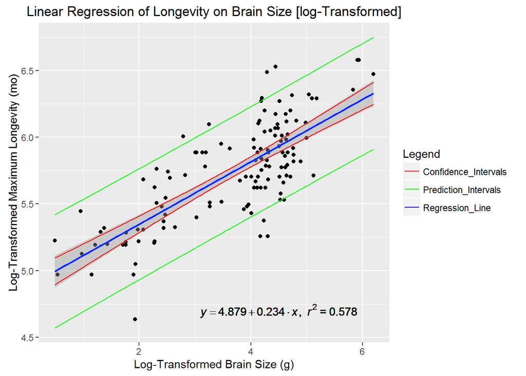

```r
> log_regression_plot <- log_regression_plot + geom_line(aes(x = df$log_brain,
+     y = df$log_fit, colour = "Regression_Line")) + geom_line(aes(x = df$log_brain,
+     y = df$log_lwr, colour = "Confidence_Intervals")) + geom_line(aes(x = df$log_brain,
+     y = df$log_upr, colour = "Confidence_Intervals")) + geom_line(data = df,
+     aes(x = df$log_brain, y = df$log_pi_lwr, colour = "Prediction_Intervals")) +
+     geom_line(data = df, aes(x = df$log_brain, y = df$log_pi_upr, colour = "Prediction_Intervals")) +
+     scale_colour_manual(name = "Legend", values = c(Regression_Line = "blue",
+         Confidence_Intervals = "red", Prediction_Intervals = "green")) + ggtitle("Linear Regression of Longevity on Brain Size [log-Transformed]")
> log_regression_plot
```

```r
> # Produce a point estimate and associated 90 percent PI for the longevity of
> # a species whose brain weight is 800 gm. Do you trust the model to predict
> # observations accurately for this value of the explanatory variable? Why or
> # why not?
>
> ## Original data:
> yhat <- predict(m, newdata = data.frame(Brain_Size_Species_Mean = 800), interval = "prediction",
+     level = 0.9)
> yhat
```

```
##        fit      lwr      upr
## 1 1223.345 1021.805 1424.884
```

```r
> ## Log-transformed data:
>
> log_yhat <- predict(log_m, newdata = data.frame(log_brain = log(800)), interval = "prediction",
+     level = 0.9)
> log_yhat
```

```
##       fit      lwr      upr
## 1 6.44415 6.021424 6.866876
```

```r
> exp(log_yhat[1, ])
```

```
##      fit      lwr      upr
## 629.0118 412.1652 959.9446
```

## Based on the regression model (m) for the original data, the point estimate of maximum longevity for a species with a mean brain size of 800 grams is 1223.345 months, or ~102 years. The prediction interval ranges from 1021.805 months, or ~85 years (lower-bound) to 1424.884 months, or ~119 years (upper-bound). It is not surprising that the range of this prediction interval is so wide when we consider the pattern of the regression plot. The majority of the species in our dataset have an average brain size of less than 200g (the exceptions being G. gorilla, G. beringei, P. paniscus, and P. troglodytes). As we can see from the confidence intervals, the degree of uncertainty increases as brain size increases. Given that even Pan and Gorilla do not exceed 500g, a point estimate for 800g is not likely to be reliable. Another indicator of the low predictive value of this regression model is the fact that the coefficient of determination (or R-Squared value) is only 0.493. Finally, even without considering specifics of the regression model, we know that 102 years is way to high of an estimate of longevity for a primate species.

## Based on the regression model (log_m) for the log-transformed data, the point estimate of maximum longevity for a species with a mean brain size of 800 grams is 629.0118 months, or ~54 years. The prediction interval ranges from 412.1652 months, or ~34 years (lower-bound) to 959.9446 months, or 80 years (upper-bound). There are several reasons why this model is better than that based on the original data. While the range of the prediction interval is still quite large in this model, the point estimate seems much more realistic based on what we know about primate life history. Additionally, the regression plot reveals a much more even spread of data points along the x-axis. By log-transforming the data, we have reduced the effect of the outliers (especially Pan & Gorilla) and (at least to some extent) normalized the distribution. This being said, I would still not put a lot of faith in the predictive value of this model. While the coefficient of determination (0.578) is higher than that of the first model, it is still not particularly high. Finally, we know that the rate at which longevity increases relative to brain size is going to decrease as brain size increases (essentially, taper off); this pattern is not conducive to a linear model.